# Boar_Data_Markdown

shelleydan

2024-11-04

The first step is to read in the Boar data (“Boar.csv”) which includes information based on their size (length) and TB status (tb). The goal of this analysis is to build a generalised linear model (GLM) to predict the possibility of a Boar being infected with TB based on their body length.

```r
boar_data <- read.csv("Boar.csv", header = T, na = "NA", stringsAsFactors = T)
```

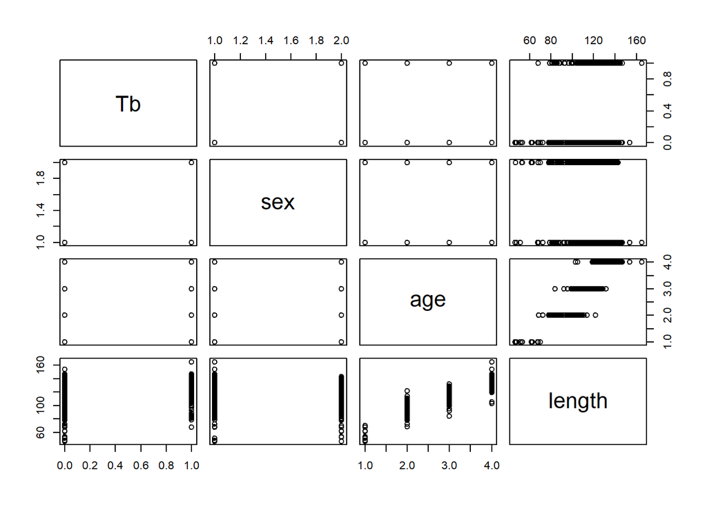

```r
pairs(boar_data)
```

Now that we understand our data format, we can start building our model. We identifiy the range of the data in length to apply to our model later. Finally we summarise our model afterwards to understand the statistical output.

```r
range(boar_data$length, na.rm = T) #Gives the range of the data input
```

```
## [1]  46.5 165.0
```

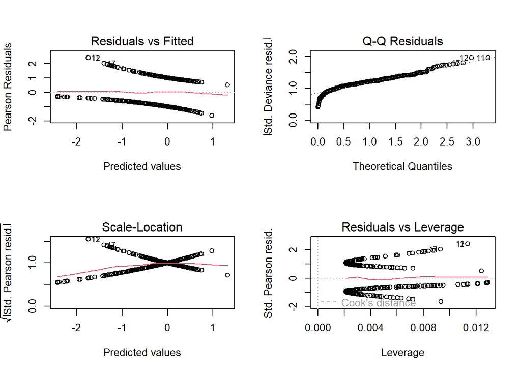

```r
model1 <- glm(Tb~length, data = boar_data, na.action = na.omit, family=binomial(link = "logit"))
par(mfrow=c(2,2))
plot(model1) #Plots the 4 residual plot.
```

```r
par(mfrow=c(1,1))

summary(model1)
```

```
##
## Call:
## glm(formula = Tb ~ length, family = binomial(link = "logit"),
##     data = boar_data, na.action = na.omit)
##
## Coefficients:
##              Estimate Std. Error z value Pr(>|z|)
## (Intercept) -3.892109   0.671152  -5.799 6.67e-09 ***
## length       0.031606   0.005588   5.656 1.55e-08 ***
## ---
## Signif. codes:  0 '***' 0.001 '**' 0.01 '*' 0.05 '.' 0.1 ' ' 1
##
## (Dispersion parameter for binomial family taken to be 1)
##
##     Null deviance: 700.76  on 507  degrees of freedom
## Residual deviance: 663.56  on 506  degrees of freedom
##   (149 observations deleted due to missingness)
## AIC: 667.56
##
## Number of Fisher Scoring iterations: 4
```

The final step is to build our prediction graphically.

```r
plot(Tb ~ length, data = boar_data)

newDat <- expand.grid(length = seq(46.5,165,0.5))

pred <- predict(model1, newdata = newDat,
                type = "response", se.fit = T, na.rm = T)
#se.fit allows you to include the standard error within it
#This expand must include all X variables we include in our model. The seq(min, max, stepwise_change/intervals)
#Why do we have different types of 'type'?

predFrame <- data.frame(pred, length = newDat$length) #Combinging the datasets
head(predFrame)
```

```
##          fit     se.fit residual.scale length
## 1 0.08147885 0.03108250              1   46.5
## 2 0.08266941 0.03128925              1   47.0
## 3 0.08387577 0.03149488              1   47.5
## 4 0.08509810 0.03169932              1   48.0
## 5 0.08633657 0.03190250              1   48.5
## 6 0.08759133 0.03210434              1   49.0
```

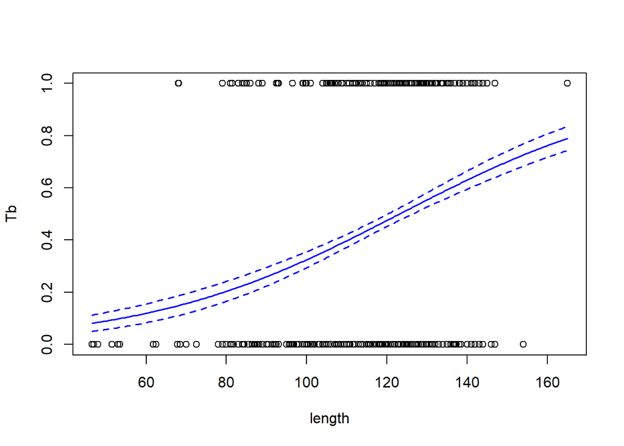

```r
plot(Tb ~ length, data = boar_data) #Empty plot of just Tb and Length

#Perfect Prediction line
lines(fit ~ length, data = predFrame, lw = 1.5, col = "blue") #Adds the middle line

#Predictions +/- the error.
lines(fit+se.fit ~ length, data = predFrame, lw = 1.5, col = "blue", lty = 2)
lines(fit-se.fit ~ length, data = predFrame, lw = 1.5, col = "blue", lty = 2)
```